# IS NLP assignment

SILI LIU

2021/1/2

# 1.Introduction

## 1.1 Problem Scoping

Nowadays, cell phone has become an essential thing in people’s life. People can use cell phone messages to communicate, but with the development of technology, cell phones will also receive some network marketing activities and even network fraud spam, these messages will make people miss some important messages, thus defeating the purpose of the message for effective communication

## 1.2 Objective of the project

The goal of this project is to build a spam filter by using some mechanical learning algorithms which can effectively classify incoming emails or text messages as “spam” or “ham”

## 1.3 Dataset Description

The dataset, from the Brazilian School of Eletrical and Computer Engineering, is called SMS Spam Collection v. 1 and contains 5,574 messages in English, real and nonattached, and is tagged according to legitimacy (ham) or spam Link of dataset:http://www.dt.fee.unicamp.br/~tiago/smsspamcollection/

# 2.Data Preprocessing

## 2.1 Check working directory

Check the working directory with `wd`. If it is not the one where your data are located, change it with `setwd`.

```r
getwd()
```

```
## [1] "C:/Users/liusi/Documents/NLP Assignment"
```

## 2.2 Load libraries

Load the required libraries.

```r
library(tm)
library(ggplot2)
library(wordcloud)
library(RWeka)
library(reshape2)
library(SnowballC)
library(NLP)
library(openNLP)
library(stringr)
library(caTools)

library(caret)
library(randomForest)
library(e1071)
```

## 2.3 Load dataset

This project is going to use the SMS Spam Collection v. 1, created by Tiago A. Almeida Once unzipped, the data has a text file “SMSSpamCollection.txt”.In this case, using `read.delim` function to import this file

```r
#Read text file
data_text <- read.delim("./smsspamcollection/SMSSpamCollection.txt", header=FALSE, sep="\t",colClasses="character",quote = "",encoding="UTF-8")
```

```r
str(data_text)
```

```
## 'data.frame':    5574 obs. of  2 variables:
##  $ V1: chr  "ham" "ham" "spam" "ham" ...
##  $ V2: chr  "Go until jurong point, crazy.. Available only in bugis n great world la e buffet... Cine there got amore wat..." "Ok lar... Joking wif u oni..." "Free entry in 2 a wkly comp to win FA Cup final tkts 21st May 2005. Text FA to 87121 to receive entry question("| __truncated__ "U dun say…
```

```r
head(data_text)
```

```
##     V1
## 1  ham
## 2  ham
## 3 spam
## 4  ham
## 5  ham
## 6 spam
##                                                                                                                                                            V2
## 1                                             Go until jurong point, crazy.. Available only in bugis n great world la e buffet... Cine there got amore wat...
## 2                                                                                                                               Ok lar... Joking wif u oni...
## 3 Free entry in 2 a wkly comp to win FA Cup final tkts 21st May 2005. Text FA to 87121 to receive entry question(std txt rate)T&C's apply 08452810075over18's
## 4                                                                                                           U dun say so early hor... U c already then say...
## 5                                                                                               Nah I don't think he goes to usf, he lives around here though
## 6        FreeMsg Hey there darling it's been 3 week's now and no word back! I'd like some fun you up for it still? Tb ok! XxX std chgs to send, ￡1.50 to rcv
```

```r
colnames(data_text)
```

```
## [1] "V1" "V2"
```

Renaming the columns into “Target” and “Content”

```r
colnames(data_text)[colnames(data_text) == 'V1'] <- 'Target'
colnames(data_text)[colnames(data_text) == 'V2'] <- 'Content'
summary(data_text)
```

```
##     Target            Content
##  Length:5574        Length:5574
##  Class :character   Class :character
##  Mode  :character   Mode  :character
```

## 2.4 Create a default document term matrix

We need to find which key words in the content of the message would be considered as spam or ham? Which words appear the most within these words and how often do they occur? We use the `DocumentTermMatrix` function to create a document term matrix (DTM)

### 2.4.1 Load corpus

```r
corpus <- VCorpus(VectorSource(data_text$Content))
as.character((corpus[[1]]))
```

```
## [1] "Go until jurong point, crazy.. Available only in bugis n great world la e buffet... Cine there got amore wat..."
```

### 2.4.2 Cleaning Data and creating the document term matrix

```r
dtm = DocumentTermMatrix(corpus,
                                    control=list(stopwords = T,
                                                 removePunctuation = T,
                                                 removeNumbers = T,
                                                 stripWhitespace = T,
                                                 stemDocument = T))
dtm
```

```
## <<DocumentTermMatrix (documents: 5574, terms: 8382)>>
## Non-/sparse entries: 44247/46677021
## Sparsity           : 100%
## Maximal term length: 40
## Weighting          : term frequency (tf)
```

```r
dtm= removeSparseTerms(dtm, 0.999)##Avid sparsity
head(dimnames(dtm)$Terms,10)
```

```
##  [1] "abiola"   "able"     "about"    "abt"      "accept"   "access"
##  [7] "account"  "across"   "activate" "actually"
```

```r
tail(dimnames(dtm)$Terms,10)
```

```
##  [1] "yesterday" "yet"       "yijue"     "yoga"      "you"       "yours"
##  [7] "yourself"  "yrs"       "yup"       "zed"
```

### 2.4.3 Create a document term matrix for SAPM messages

Now we need to create a TDM specifically for SAPM messages

```r
data_text_SPAM <- data_text[which(data_text$Target == 'spam'),]
corpus_SPAM <- VCorpus(VectorSource(data_text_SPAM$Content))
dtm_SPAM = DocumentTermMatrix(corpus_SPAM,
                                    control=list(stopwords = T,
                                                 removePunctuation = T,
                                                 removeNumbers = T,
                                                 stripWhitespace = T,
                                                 stemDocument = T))
dtm_SPAM= removeSparseTerms(dtm_SPAM, 0.995)##Avid sparsity
```

# 3. Analysis of the data

## 3.1 Word Frequency

List the frequency of word occurrences in the full data

```r
freq=sort(colSums(as.matrix(dtm)),decreasing=TRUE)
head(freq,10)
```

```
## call  now  can  get will just free ltgt know like
##  580  479  405  390  383  368  278  276  257  244
```

```r
tail(freq,10)
```

```
##      wed wherever  willing      wnt    works      wwq      yay    yijue
##        6        6        6        6        6        6        6        6
## yourself      zed
##        6        6
```

Now we look for the frequency of words appearing in SPAM messages

```r
freq_SPAM=sort(colSums(as.matrix(dtm_SPAM)),decreasing=TRUE)
head(freq_SPAM,60)
```

```
##       call       free        now        txt     mobile       text       stop
##        349        219        190        150        124        121        118
##      claim      reply      prize        get       just        won        new
##        113        101         92         83         78         73         69
##      nokia       send     urgent       cash        win    contact    service
##         69         68         63         62         61         56         55
##     please guaranteed   customer       week        box       tone        per
##         54         50         49         49         48         48         46
##      phone        ppm       will       chat    awarded       draw       mins
##         46         44         44         43         38         38         38
##     latest       line        you     camera      every    receive    holiday
##         36         35         35         33         33         33         32
##   landline    message      shows      apply     number      pobox        can
##         32         32         31         30         30         30         29
##       code       live        tcs      video       want      award     chance
##         29         29         29         29         29         28         27
##        msg collection      entry     orange
##         27         26         26         26
```

```r
tail(freq_SPAM,10)
```

```
##                 tkts                 trip           txtauction
##                    4                    4                    4
##                txtin                  wan                wcnxx
##                    4                    4                    4
## wwwldewcomwinppmxage     wwwringtonescouk                  wwx
##                    4                    4                    4
##                  yer
##                    4
```

## 3.2 Plotting Word Frequency

The top 10 most common terms and their frequencies are displayed in the bar chart.

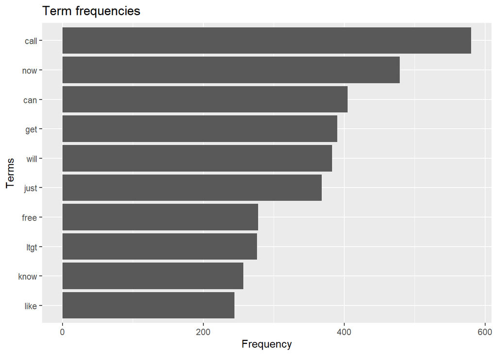

```r
high.freq=tail(sort(freq),n=10)
hfp.df=data.frame(names=names(high.freq),freq=high.freq)
ggplot(hfp.df, aes(reorder(names,high.freq),high.freq)) +
  geom_bar(stat="identity") + coord_flip() +
  xlab("Terms") + ylab("Frequency") +
  ggtitle("Term frequencies")
```

For SPAM messages

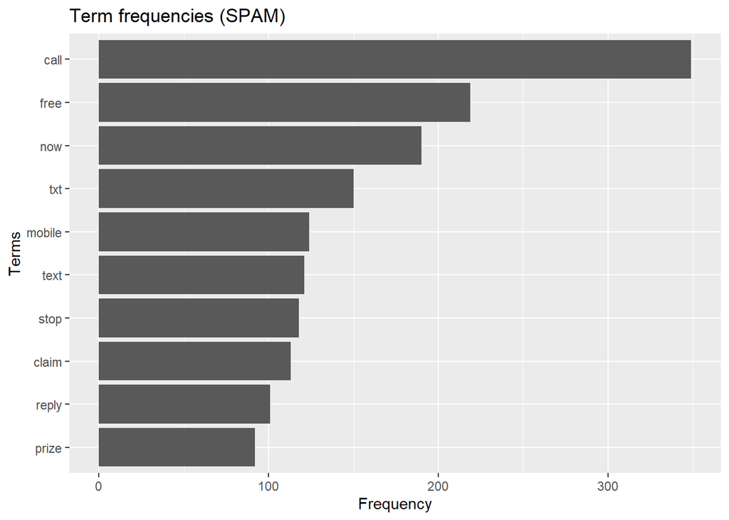

```r
high.freq_SPAM=tail(sort(freq_SPAM),n=10)
hfp.df_SPAM=data.frame(names=names(high.freq_SPAM),freq=high.freq_SPAM)
ggplot(hfp.df_SPAM, aes(reorder(names,high.freq_SPAM), high.freq_SPAM)) +
  geom_bar(stat="identity") + coord_flip() +
  xlab("Terms") + ylab("Frequency") +
  ggtitle("Term frequencies (SPAM)")
```

## 3.3 Create a word cloud

Presenting the word frequency as a word cloud

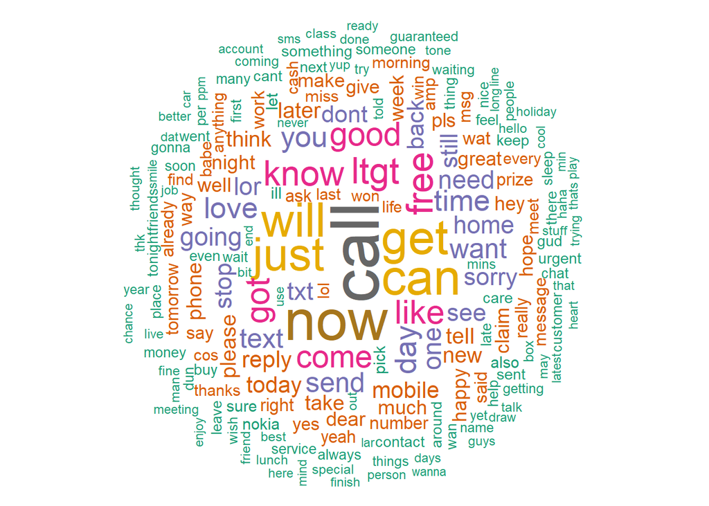

```r
set.seed(1234)
wordcloud(words = names(freq), freq = freq, min.freq = 1,
          max.words=200, random.order=FALSE, rot.per=0.35,
          colors=brewer.pal(8, "Dark2"))
```

In the SPAM messages data

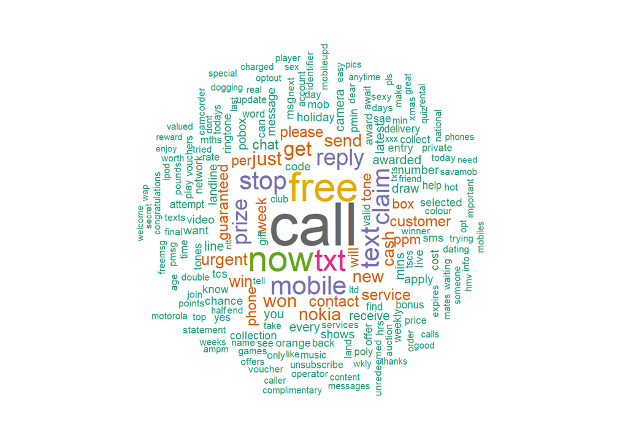

```r
set.seed(1234)
wordcloud(words = names(freq_SPAM), freq = freq_SPAM, min.freq = 1,
          max.words=200, random.order=FALSE, rot.per=0.35,
          colors=brewer.pal(8, "Dark2"))
```

# 4. Annotate corpus and find simple patterns

In this part, we use some of the functions in the example to apply to each document in the corpus, using on top of the SPAM information file, we can get the number of appearances of certain keywords inside some SPAM messages that we meet in life

## 4.1 Auxiliary functions

### detectPatternOnDocument

```r
detectPatternOnDocument <- function(doc, pattern) {
  x=as.String(doc)
  res=str_match_all(x,pattern)

  dimrow=dim(res[[1]])[1]
  dimcol=dim(res[[1]])[2]

  # If there are no rows, no matches have been found
  if (dimrow == 0) {
    return(NA)
  }else{
    if (dimcol > 2){
      # If there are three or more columns, we have to paste all the groups together
      for (i in 1:dimrow) {
        res[[1]][i,2] = paste(res[[1]][i,2:dimcol], collapse = ' ')
      }
    }

    # We return all the results found separated by ','
    if (dimcol != 1) {
      result = paste(res[[1]][,2], collapse = ', ')
    }else{
      result = paste(res[[1]][,1], collapse = ', ')
    }
    return(result)
  }
}
```

### detectPatternsInCorpus

```r
detectPatternsInCorpus = function(corpus, patterns){
  vallEntities <- data.frame(matrix(NA, ncol = length(patterns)+1,
                                    nrow = length(corpus)))
  names(vallEntities) <- c("File",patterns)
  for (i in 1:length(patterns)) {
    vallEntities[,i+1]=unlist(lapply(corpus, detectPatternOnDocument,
                                     pattern=patterns[i]))
    }
  for (i in 1:length(corpus)) {
    vallEntities$File[i]=meta(corpus[[i]])$id
    }
  return (vallEntities)
}
```

### countMatchesPerRow

```r
countMatchesPerRow = function (df) {
  entityCountPerFile <- data.frame(matrix(NA, ncol = 2, nrow = nrow(df)))
  names(entityCountPerFile) <- c("File","Count")

  for (i in 1:nrow(df)) {
    entityCountPerFile$File[i] = df$File[i]
    entityCountPerFile$Count[i] = length(Filter(Negate(is.na),df[i,2:length(df[i,])]))
    }
  return (entityCountPerFile[entityCountPerFile[2]!=0,])
}
```

### countMatchesPerColumn

```r
countMatchesPerColumn = function (df) {
  entityCountPerPattern <- data.frame(matrix(NA, ncol = 2,
                                             nrow = length(names(df))-1))
  names(entityCountPerPattern) <- c("Entity","Count")

  for (i in 2:length(names(df))) {
    entityCountPerPattern$Entity[i-1] = names(df)[i]
    entityCountPerPattern$Count[i-1] = nrow(subset(df, !is.na(df[i])))
    }
  return (entityCountPerPattern)
  }
```

## 4.2 Result

I have selected some keywords of deceptive information that I often encounter in my daily life. For example, “win”, “free”, “award”, etc.

```r
pattern0=c("win")
pattern0=c(pattern0,"won")
pattern0=c(pattern0,"award[ed]?")
pattern0=c(pattern0,"free")
pattern0=c(pattern0,"Free")

matches0 = detectPatternsInCorpus(corpus_SPAM, pattern0)
countMatchesPerRow(matches0)
```

```
##     File Count
## 1      1     2
## 2      2     1
## 4      4     1
## 5      5     1
## 6      6     1
## 10    10     1
## 13    13     2
## 14    14     1
## 17    17     1
## 18    18     1
## 19    19     1
## 21    21     1
## 22    22     1
## 26    26     1
```

[output cut: 228 more lines]

```r
countMatchesPerColumn(matches0)
```

```
##       Entity Count
## 1        win    65
## 2        won    52
## 3 award[ed]?    57
## 4       free    61
## 5       Free    57
```

# 5. Model Building

## 5.1 Convert the matrix into a data frame

```r
dataset = as.data.frame(as.matrix(dtm))
colnames(dataset) = make.names(colnames(dataset))
dataset$Target=data_text$Target

prop.table(table(dataset$Target))
```

```
##
##       ham      spam
## 0.8659849 0.1340151
```

## 5.2 Splitting the dataset into the Training set and Test set

We split the data in the ratio of 70% training set and 30% test set

```r
set.seed(1234)
split = sample.split(dataset$Target, SplitRatio = 0.7)

train = subset(dataset, split==TRUE)
test = subset(dataset, split==FALSE)

prop.table(table(train$Target))
```

```
##
##       ham      spam
## 0.8659662 0.1340338
```

```r
prop.table(table(test$Target))
```

```
##
##       ham      spam
## 0.8660287 0.1339713
```

```r
train$Target= as.factor(train$Target)
test$Target = as.factor(test$Target )
```

## 5.3 Model Building

### 5.3.1 Random Forest

```r
RF_model =  randomForest(
  Target ~ .,
  data=train
)

predictRF = predict(RF_model, newdata=test)
confusionMatrix(table(predictRF,test$Target))
```

```
## Confusion Matrix and Statistics
##
##
## predictRF  ham spam
##      ham  1443   34
##      spam    5  190
##
##                Accuracy : 0.9767
##                  95% CI : (0.9683, 0.9834)
##     No Information Rate : 0.866
##     P-Value [Acc > NIR] : < 2.2e-16
##
##                   Kappa : 0.8937
##
##  Mcnemar's Test P-Value : 7.34e-06
##
##             Sensitivity : 0.9965
##             Specificity : 0.8482
##          Pos Pred Value : 0.9770
##          Neg Pred Value : 0.9744
##              Prevalence : 0.8660
##          Detection Rate : 0.8630
##    Detection Prevalence : 0.8834
##       Balanced Accuracy : 0.9224
##
##        'Positive' Class : ham
##
```

### 5.3.2 Support Vector Machine

```r
SVM_model =  svm(
  Target ~ .,
  data=train
)
predictSVM = predict(SVM_model, newdata=test)
confusionMatrix(table(predictSVM,test$Target))
```

```
## Confusion Matrix and Statistics
##
##
## predictSVM  ham spam
##       ham  1448   67
##       spam    0  157
##
##                Accuracy : 0.9599
##                  95% CI : (0.9494, 0.9688)
##     No Information Rate : 0.866
##     P-Value [Acc > NIR] : < 2.2e-16
##
##                   Kappa : 0.8023
##
##  Mcnemar's Test P-Value : 7.433e-16
##
##             Sensitivity : 1.0000
##             Specificity : 0.7009
##          Pos Pred Value : 0.9558
##          Neg Pred Value : 1.0000
##              Prevalence : 0.8660
##          Detection Rate : 0.8660
##    Detection Prevalence : 0.9061
##       Balanced Accuracy : 0.8504
##
##        'Positive' Class : ham
##
```

### 5.3.3 Cross Validation Decision Tree (rpart)

```r
fitControl <- trainControl(method = "cv",
                            number = 10,
                           classProbs=TRUE,
                           summaryFunction=twoClassSummary)
CV_tree <- train(Target ~., train,
                   trControl=fitControl,
                    metric='ROC',
                    method='rpart')
predictTree<- predict(CV_tree, test)
confusionMatrix(predictTree, test$Target)
```

```
## Confusion Matrix and Statistics
##
##           Reference
## Prediction  ham spam
##       ham  1394   87
##       spam   54  137
##
##                Accuracy : 0.9157
##                  95% CI : (0.9013, 0.9285)
##     No Information Rate : 0.866
##     P-Value [Acc > NIR] : 1.643e-10
##
##                   Kappa : 0.6124
##
##  Mcnemar's Test P-Value : 0.007041
##
##             Sensitivity : 0.9627
##             Specificity : 0.6116
##          Pos Pred Value : 0.9413
##          Neg Pred Value : 0.7173
##              Prevalence : 0.8660
##          Detection Rate : 0.8337
##    Detection Prevalence : 0.8858
##       Balanced Accuracy : 0.7872
##
##        'Positive' Class : ham
##
```

# 6. Conclusion

In this project, 3 different simple mechanical learning models are used.

From the above 3 model structures, it can be seen that it is viable to construct filters for spam massage by mechanical learning algorithms. In the same case, such filters can be used in the email domain. The dataset in this project has 5574 cell phone messages, and with the addition of new data, the prediction model will have more training sets, thus improving the model prediction accuracy.